# D207 P.A. :

[Link to the Panopto Video](https://wgu.hosted.panopto.com/Panopto/Pages/Viewer.aspx?id=4b7a6a14-3a26-45b2-b220-acfc00556019)

https://wgu.hosted.panopto.com/Panopto/Pages/Viewer.aspx?id=4b7a6a14-3a26-45b2-b220-acfc00556019

###### -------------------------------------------------------------------------------------------------------------------------------------------------------------------------------------------------------

#### A. Describe a real-world organizational situation or issue in the Data Dictionary you chose, by doing the following:

###### A1. Provide one question that is relevant to your chosen data set. You will answer this question later in the task through an analysis of the cleaned data, using one of the following techniques: chi-square, t-test, or analysis of variance (ANOVA).

The Churn Data set consists of 10,000 customers and 50 columns/ variables, some variables showed high correlation with the Churn and can be used for churn probability prediction. The question to be asked is about recognizing which variables have a relationship with the customer's Churn, and to what extent these relationships are reliable and can be used to predict customers churn probability?

###### A2. Explain how stakeholders in the organization could benefit from an analysis of the data.

“Given that it costs 10 times more to acquire a new customer than to retain an existing one, customer retention has now become even more important than customer acquisition. For many providers, retaining highly profitable customers is the number one business goal. To reduce customer churn, telecommunications companies need to predict which customers are at high risk of churn.” (D207 D208 D209 Churn Data Consideration and Dictionary.pdf) In addition to prediction, the company may be interested in finding the main factors that may affect the churn possibility positively and negatively, therefore taking the right actions to deal with those factors. The analysis of the data would give the company and the stakeholders a good idea about these factors and the degree of their reliability.

###### A3. Identify all of the data in your data set that are relevant to answering your question in part A1

The Data are relevant to answering the question in part A1 are the variables that can explain a significant amount of variance in the 'Churn' variable , these variables (or features) can be continuous or categorical variables. One way to identify these variables is by using Statistical Experiments and Significance Testing , which can help (to some extent) in measuring how significantly each variable can explain an amount of variance in 'Churn' , this is related to the degree of correlation between 'Churn' and each of the variables. Correlation technically can measure this amount of variance explaination but only between numweic variables, while Statistical Experiments can find out the Significance for categorical variables. In order to identify all of the data in the data set that are relevant to answering the question in part A1, I have applied different techniques such as correlation , Chi2 testing and Data visualization and it is explained in details in the following sections.

## Exploring the Data

#### Importing Libraries:

```python
#imporing the needed libraries.

import pandas as pd
pd.set_option('display.max_rows', None)
pd.set_option('display.max_columns', None) #modified Pandas options to fully display the large dataset when needed
## !!! Trying to Display a full Dataframe may cause a problem.

import numpy as np
import matplotlib.pyplot as plt
import seaborn as sns
import scipy.stats as stats
```

#### Reading the CSV Data:

```python
#Reading the Data file (As received) churn_clean.csv
df_raw= pd.read_csv('churn_clean.csv')

#Created a copy of Data to edit
df_ed=df_raw.copy()

# 'Churn' Binary values replacement (Yes/No)
df_ed['Churn']=df_ed['Churn'].replace({'Yes':1,'No':0})
```

#### Data info:

```python
df_raw.info() #Data Information of the Raw DataFrame (As received)
```

```
<class 'pandas.core.frame.DataFrame'>
RangeIndex: 10000 entries, 0 to 9999
Data columns (total 50 columns):
 #   Column                Non-Null Count  Dtype
---  ------                --------------  -----
 0   CaseOrder             10000 non-null  int64
 1   Customer_id           10000 non-null  object
 2   Interaction           10000 non-null  object
 3   UID                   10000 non-null  object
 4   City                  10000 non-null  object
 5   State                 10000 non-null  object
 6   County                10000 non-null  object
 7   Zip                   10000 non-null  int64
 8   Lat                   10000 non-null  float64
 9   Lng                   10000 non-null  float64
```

[output cut: 42 more lines]

#### Summary statistics:

```python
#Summary statistics of Numerical variables of the Raw DataFrame
df_raw.describe().T  #Transposed to show large number of variables displayed as rows
```

|  | count | mean | std | min | 25% | 50% | 75% | max |
| --- | --- | --- | --- | --- | --- | --- | --- | --- |
| CaseOrder | 10000.0 | 5000.500000 | 2886.895680 | 1.000000 | 2500.750000 | 5000.500000 | 7500.250000 | 10000.000000 |
| Zip | 10000.0 | 49153.319600 | 27532.196108 | 601.000000 | 26292.500000 | 48869.500000 | 71866.500000 | 99929.000000 |
| Lat | 10000.0 | 38.757567 | 5.437389 | 17.966120 | 35.341828 | 39.395800 | 42.106908 | 70.640660 |
| Lng | 10000.0 | -90.782536 | 15.156142 | -171.688150 | -97.082813 | -87.918800 | -80.088745 | -65.667850 |
| Population | 10000.0 | 9756.562400 | 14432.698671 | 0.000000 | 738.000000 | 2910.500000 | 13168.000000 | 111850.000000 |
| Children | 10000.0 | 2.087700 | 2.147200 | 0.000000 | 0.000000 | 1.000000 | 3.000000 | 10.000000 |
| Age | 10000.0 | 53.078400 | 20.698882 | 18.000000 | 35.000000 | 53.000000 | 71.000000 | 89.000000 |
| Income | 10000.0 | 39806.926771 | 28199.916702 | 348.670000 | 19224.717500 | 33170.605000 | 53246.170000 | 258900.700000 |
| Outage_sec_perweek | 10000.0 | 10.001848 | 2.976019 | 0.099747 | 8.018214 | 10.018560 | 11.969485 | 21.207230 |
| Email | 10000.0 | 12.016000 | 3.025898 | 1.000000 | 10.000000 | 12.000000 | 14.000000 | 23.000000 |
| Contacts | 10000.0 | 0.994200 | 0.988466 | 0.000000 | 0.000000 | 1.000000 | 2.000000 | 7.000000 |
| Yearly_equip_failure | 10000.0 | 0.398000 | 0.635953 | 0.000000 | 0.000000 | 0.000000 | 1.000000 | 6.000000 |
| Tenure | 10000.0 | 34.526188 | 26.443063 | 1.000259 | 7.917694 | 35.430507 | 61.479795 | 71.999280 |
| MonthlyCharge | 10000.0 | 172.624816 | 42.943094 | 79.978860 | 139.979239 | 167.484700 | 200.734725 | 290.160419 |
| Bandwidth_GB_Year | 10000.0 | 3392.341550 | 2185.294852 | 155.506715 | 1236.470827 | 3279.536903 | 5586.141369 | 7158.981530 |
| Item1 | 10000.0 | 3.490800 | 1.037797 | 1.000000 | 3.000000 | 3.000000 | 4.000000 | 7.000000 |
| Item2 | 10000.0 | 3.505100 | 1.034641 | 1.000000 | 3.000000 | 4.000000 | 4.000000 | 7.000000 |
| Item3 | 10000.0 | 3.487000 | 1.027977 | 1.000000 | 3.000000 | 3.000000 | 4.000000 | 8.000000 |
| Item4 | 10000.0 | 3.497500 | 1.025816 | 1.000000 | 3.000000 | 3.000000 | 4.000000 | 7.000000 |
| Item5 | 10000.0 | 3.492900 | 1.024819 | 1.000000 | 3.000000 | 3.000000 | 4.000000 | 7.000000 |
| Item6 | 10000.0 | 3.497300 | 1.033586 | 1.000000 | 3.000000 | 3.000000 | 4.000000 | 8.000000 |
| Item7 | 10000.0 | 3.509500 | 1.028502 | 1.000000 | 3.000000 | 4.000000 | 4.000000 | 7.000000 |
| Item8 | 10000.0 | 3.495600 | 1.028633 | 1.000000 | 3.000000 | 3.000000 | 4.000000 | 8.000000 |

#### Data visualization:

*Function plt_summary() to inspect the data visually usind Histogram, Boxplot and scattered plots. The following function is defined to visually identify statistical parameters and to get the sense from the Data, such as identify the outliers , ranges, dominant values,.etc

```python
'''
Custom function to inspect the data visually using Histogram/Bar, Boxplot and scattered plots
this function takes 2 parameters, 1st is DataFrame , 2nd is the preferable plot ("hist" , "box" , " scat" , "churn_scat" or "churn_histplot" )
For Histograms with non-numeric columns , the function will use Bar charts (in Green color) instead of Histogram
"scat": plotting scatterd plot against the 1st column of the D.F.
"churn_scat": plotting scatterd plot of num. variables against the 'Churn' column of the D.F.
"churn_histplot":plotting histplot of numeric or countplot of cat. variables against the 'Churn' column
'''

def plt_summary(df_1,plt_type):
    numerics = ['int16', 'int32', 'int64', 'float16', 'float32', 'float64']

    if plt_type =='churn_histplot':
        pltlist=df_1.columns
#         for number,cols in enumerate(df_1.columns):
#             if (len(df_1[cols].value_counts())>=20):
#                 pltlist.remove(cols)
        print("Number of columns:  "+str(len(pltlist))) #Printing the number of columns.

    elif plt_type =='hist':
        pltlist=df_1.columns
        print("Number of columns:  "+str(df_1.shape[1])) #Printing the number of columns.

    else :
        df_n = df_1.select_dtypes(include=numerics).copy()   # selecting only the numeric columns as it's suitable for mentioned plots
        pltlist=df_n.columns
        print("Number of Numeric columns:  "+str(df_n.shape[1])) #Printing the number of numeric columns.


    plt.style.use('default')
    plt.figure(figsize=(15,30))
    plt_rows = 11
    plt_cols = 5

    for n, col in enumerate(pltlist):   #enumerating each column of the data, starting from index
        b=n+1
        ax=plt.subplot2grid(shape=(plt_rows,plt_cols),loc=((int(np.ceil(b/plt_cols)-1)),((b-1)%plt_cols)))
        if plt_type == 'hist':
            if df_1[col].dtype in numerics:
                ax.hist(df_1.loc[:,col],bins = 50)  #plotting Histogram
                ax.set_title(str(col)+' (*num)')
            else:
                if len(df_1[col].value_counts())>2000:
                    ax.set_title(str(col)+' ('+str(len(df_1[col].value_counts()))+' unq val.)')
                    continue
                df_1.groupby(col).size().plot.bar(rot=0,color='g') #plotting Bar chart
                ax.set_title(str(col)+' (*categ. '+str(len(df_1[col].value_counts()))+' cat.)')
                if len(df_1[col].value_counts())>20:
                    ax.tick_params(bottom=False,labelbottom=False)

        elif plt_type == 'box':
            msk = ~np.isnan(df_n.loc[:,col])
            ax.boxplot(df_n.loc[msk,col])  #plotting Box plot (used a mask to filter the null values)
            #ax.boxplot(df.loc[:,col])
            ax.set_title(col)
        elif plt_type == 'scat':
            ax.scatter(df_n.iloc[:,0],df_n.loc[:,col],s=0.1,alpha=0.1) #plotting scatterd plot against the 1st column of the D.F.
            ax.set_title(col)

        elif plt_type == 'churn_scat':
            ax.scatter(df_n.loc[:,'Churn'],df_n.loc[:,col],s=30,alpha=0.1,color='g') #plotting scatterd plot of num. variables against the 'Churn' column of the D.F.
            ax.set_title(col)

        elif plt_type == 'churn_histplot':
            ax.set_title(str(col)+' (*categ. '+str(len(df_1[col].value_counts()))+' cat.)')
            if (len(df_1[col].value_counts())<=700):
                sns.countplot(ax=ax, data = df_1,x = col,hue = 'Churn',alpha=0.7) #plotting countplot of cat. variables against the 'Churn' column
                if len(df_1[col].value_counts())>20:
                    ax.tick_params(bottom=False,labelbottom=False)
#                 for i, p in enumerate(ax.patches):
#                     height = p.get_height()
#                     ax.text(p.get_x()+p.get_width()/2., height + 0.1, height,ha="center")
            elif (df_1[col].dtype in numerics):
                    sns.histplot(df_1, x=col, hue='Churn', element="poly",ax=ax) #plotting histplot of num. variables against the 'Churn' column
                    ax.set_title(str(col)+' (*num)')
    plt.tight_layout()
    plt.show()

    return
```

```
Number of columns:  50
```

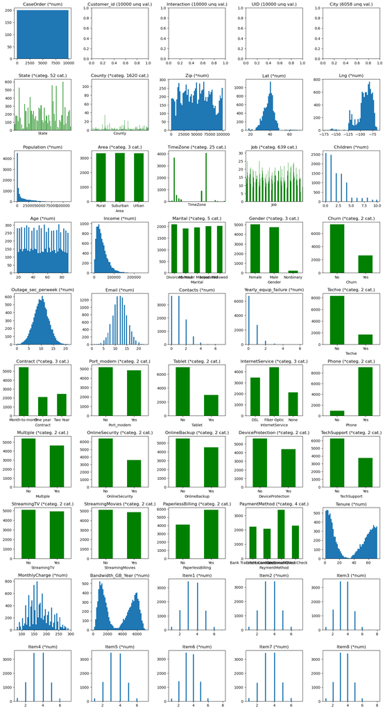

```python
#calling the plt_summary to the Raw DataFrame
plt_summary(df_raw,"hist")
```

```
Number of columns:  50
```

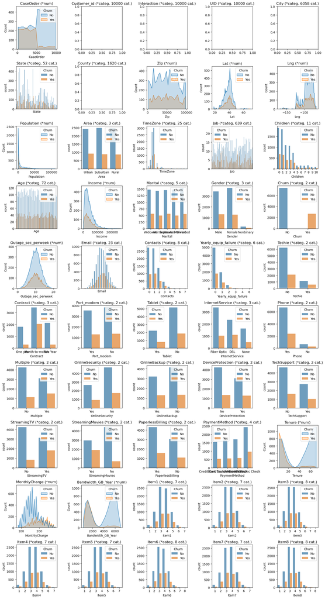

```python
#calling the plt_summary to the Raw DataFrame
plt_summary(df_raw,"churn_histplot")
```

#### Variables Correlation:

*Function plot_corr_ellipses() imported and modified From text Book "Practical Statistics for Data Scientists: 50+ Essential Concepts Using R and Python",(Bruce et al.,2020) - The associated GitHub code repository

https://github.com/gedeck/practical-statistics-for-data-scientists/blob/master/python/notebooks/Chapter%201%20-%20Exploratory%20Data%20Analysis.ipynb

```python
'''
From text Book "Practical Statistics for Data Scientists: 50+ Essential Concepts Using R and Python"
The associated GitHub code repository
'''

from matplotlib.collections import EllipseCollection
from matplotlib.colors import Normalize

def plot_corr_ellipses(data, figsize=None, **kwargs):
    ''' https://stackoverflow.com/a/34558488 '''
    M = np.array(data)
    if not M.ndim == 2:
        raise ValueError('data must be a 2D array')
    fig, ax = plt.subplots(1, 1, figsize=figsize, subplot_kw={'aspect':'equal'})
    ax.set_xlim(-0.5, M.shape[1] - 0.5)
    ax.set_ylim(-0.5, M.shape[0] - 0.5)
    ax.invert_yaxis()

    # xy locations of each ellipse center
    xy = np.indices(M.shape)[::-1].reshape(2, -1).T

    # set the relative sizes of the major/minor axes according to the strength of
    # the positive/negative correlation
    w = np.ones_like(M).ravel() + 0.01
    h = 1 - np.abs(M).ravel() - 0.01
    a = 45 * np.sign(M).ravel()

    ec = EllipseCollection(widths=w, heights=h, angles=a, units='x', offsets=xy,
                           norm=Normalize(vmin=-1, vmax=1),
                           transOffset=ax.transData, array=M.ravel(), **kwargs)
    ax.add_collection(ec)

    # if data is a DataFrame, use the row/column names as tick labels
    if isinstance(data, pd.DataFrame):
        ax.set_xticks(np.arange(M.shape[1]))
        ax.set_xticklabels(data.columns, rotation=90)
        ax.tick_params(axis="x", bottom=True, top=True, labelbottom=True, labeltop=True)
        ax.set_yticks(np.arange(M.shape[0]))
        ax.set_yticklabels(data.index)
        ax.grid (True, color = "grey", linewidth = "0.5", linestyle = "-")
    return ec
```

#### *Optional - Converting Binary categories into numeric:

To be able to correlate the categorical variables

*Function cat2num() : to convert categorical variables into serial numeric values in integer format

```python
'''
Custom function to convert categorical variables into numeric form.
this function takes 1 parameters, input DataFrame and creates a dectionary for each categorical variable
where dictinary keys are the categogries and the values are serial numeric values
the maximum number of categories this function can handle is 7000
'''
def cat2num(df_1):
    numerics = ['int16', 'int32', 'int64', 'float16', 'float32', 'float64']
    df_num_conv=df_1.copy()
    for n, col in enumerate(df_num_conv.columns):
        if (df_num_conv[col].dtype in numerics) or (len(df_num_conv[col].value_counts())>7000):
            continue
        else:
            cat_dict={y:x for x,y in enumerate(dict(df_raw[col].value_counts()))}
            df_num_conv[col]=df_num_conv[col].replace(cat_dict)
    return df_num_conv
```

```python
# To be able to correlate the categorical variables
df_num=cat2num(df_raw)
```

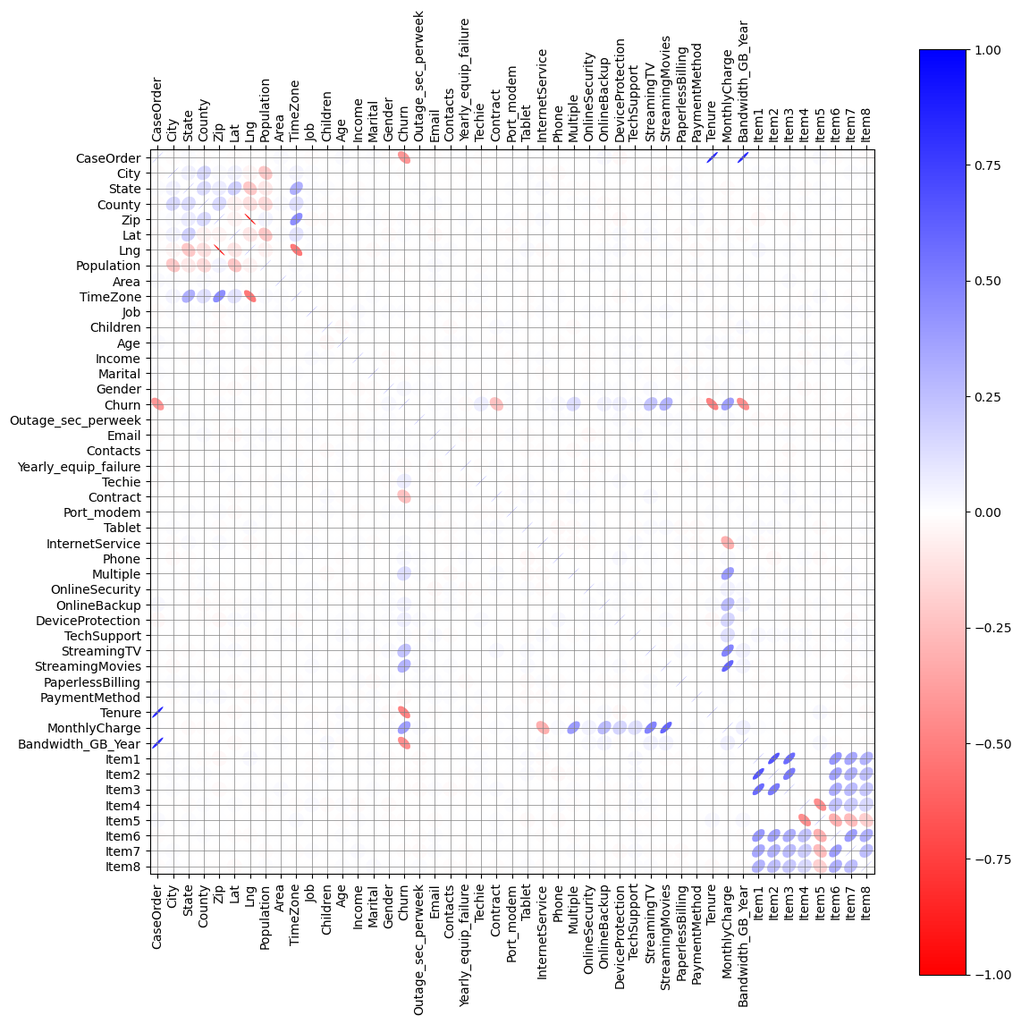

```python
ax= plot_corr_ellipses(df_num.corr(), figsize=(12, 12), cmap='bwr_r')
plt.colorbar(ax)
plt.tight_layout()
plt.show()
```

###### -------------------------------------------------------------------------------------------------------------------------------------------------------------------------------------------------------

#### B. Describe the data analysis by doing the following:

###### B1. Using one of the following techniques, write code (in either Python or R) to run the analysis of the data set:

```
•   chi-square -(Selected).
•   t-test
•   ANOVA
```

#### Chi-square implementation

*Function chi2_multiple() , apply chi2 test to each variable in dataframe vs. target variable (Churn)

```python
'''
Custom function to apply Chi2 to multiple variables
this function takes 2 parameters, 1st is DataFrame , 2nd is the target variable for Chi2 analysis ('Churn')
The output is a data frame with the Chi2 reults including ('chi2','p-val','dof') for each variable.
'''
def chi2_multiple(df_1,target):
    numerics = ['int16', 'int32', 'int64', 'float16', 'float32', 'float64']
    col_l=[];chi2_l=[];p_l=[];dof_l=[]
    for n,col in enumerate(df_raw.columns):
        #if (not df_raw[col].dtype in numerics) and (len(df_raw[col].value_counts())<2000):
            rows,colms=col,target
            df_crostab=pd.crosstab(index=df_raw[colms],columns=df_raw[rows],margins = False)
            (chi2,p,dof,_)=stats.chi2_contingency([df_crostab.iloc[x].values for x in range(0,df_crostab.shape[0])])
            col_l.append(col);chi2_l.append(chi2);p_l.append(p);dof_l.append(dof)
    data={'variable':col_l,'chi2':chi2_l,'p-val':p_l,'dof':dof_l}
    df = pd.DataFrame(data=data,columns = ['variable','chi2','p-val','dof'])
    df.set_index('variable',drop=True,inplace= True)
    print('*Chi2 for categorical variables vs. "'+ target+'"')
    return df.sort_values(by='p-val',axis=0,ascending=True)
    #return df.sort_values(by='chi2',axis=0,ascending=False)
```

###### B2. Provide the output and the results of any calculations from the analysis you performed.

Applying chi2 test to multiple variables vs "Churn" using chi2_multiple() function

```python
chi2_tst=chi2_multiple(df_raw,'Churn')
chi2_tst
```

```
*Chi2 for categorical variables vs. "Churn"
```

| variable | chi2 | p-val | dof |
| --- | --- | --- | --- |
| Churn | 9994.866530 | 0.000000e+00 | 1 |
| MonthlyCharge | 3026.011686 | 2.995658e-270 | 749 |
| StreamingMovies | 835.414013 | 1.078010e-183 | 1 |
| Contract | 718.591581 | 9.116348e-157 | 2 |
| StreamingTV | 528.651861 | 5.549381e-117 | 1 |
| Multiple | 173.037988 | 1.605732e-39 | 1 |
| InternetService | 87.462046 | 1.018259e-19 | 2 |
| Techie | 44.114794 | 3.096716e-11 | 1 |
| DeviceProtection | 31.653203 | 1.843103e-08 | 1 |
| OnlineBackup | 25.281554 | 4.954241e-07 | 1 |
| Phone | 6.711745 | 9.577997e-03 | 1 |
| Gender | 7.880065 | 1.944758e-02 | 2 |
| PaymentMethod | 9.437373 | 2.400702e-02 | 3 |
| TechSupport | 3.461224 | 6.282377e-02 | 1 |
| County | 1673.899146 | 1.670805e-01 | 1619 |
| OnlineSecurity | 1.769750 | 1.834130e-01 | 1 |
| Yearly_equip_failure | 6.925268 | 2.262578e-01 | 5 |
| Marital | 5.565781 | 2.340075e-01 | 4 |
| Area | 2.439074 | 2.953669e-01 | 2 |
| Lng | 8687.374321 | 3.269231e-01 | 8629 |
| Lat | 8606.083943 | 3.664020e-01 | 8562 |
| Zip | 8624.053395 | 3.723809e-01 | 8582 |
| Job | 648.344859 | 3.795400e-01 | 638 |
| Email | 23.111270 | 3.954694e-01 | 22 |
| Population | 5957.095526 | 4.066413e-01 | 5932 |
| Port_modem | 0.628905 | 4.277571e-01 | 1 |
| Item7 | 5.637877 | 4.649514e-01 | 6 |
| State | 51.185368 | 4.663759e-01 | 51 |
| Item5 | 5.624900 | 4.664912e-01 | 6 |
| Tenure | 10000.000000 | 4.840173e-01 | 9995 |
| Income | 9994.865871 | 4.900328e-01 | 9992 |
| Bandwidth_GB_Year | 10000.000000 | 4.952984e-01 | 9999 |
| CaseOrder | 10000.000000 | 4.952984e-01 | 9999 |
| Interaction | 10000.000000 | 4.952984e-01 | 9999 |
| Customer_id | 10000.000000 | 4.952984e-01 | 9999 |
| UID | 10000.000000 | 4.952984e-01 | 9999 |
| PaperlessBilling | 0.462398 | 4.965052e-01 | 1 |
| Outage_sec_perweek | 9982.030548 | 5.065014e-01 | 9985 |
| Item2 | 5.272410 | 5.093789e-01 | 6 |
| City | 6039.305616 | 5.615354e-01 | 6057 |
| Contacts | 5.521845 | 5.965503e-01 | 7 |
| Item3 | 5.370560 | 6.148391e-01 | 7 |
| Item1 | 4.332078 | 6.318336e-01 | 6 |
| Children | 6.580539 | 7.643619e-01 | 10 |
| Item6 | 4.129357 | 7.647633e-01 | 7 |
| Age | 61.972271 | 7.690482e-01 | 71 |
| Tablet | 0.064075 | 8.001681e-01 | 1 |
| Item4 | 2.961095 | 8.137138e-01 | 6 |
| TimeZone | 15.187142 | 9.151631e-01 | 24 |
| Item8 | 1.713972 | 9.739656e-01 | 7 |

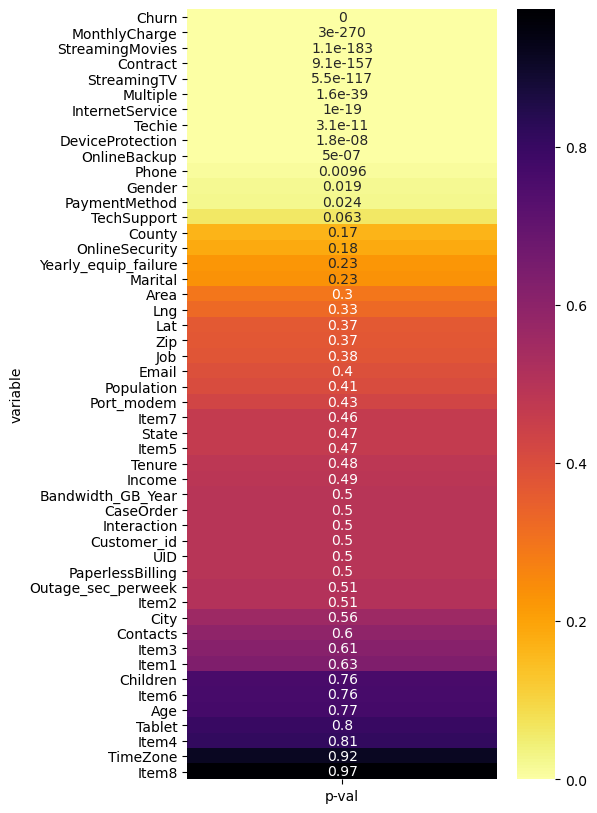

```python
plt.figure(figsize=(5,10))
sns.heatmap(chi2_tst.iloc[:,[1]],cmap="inferno_r", annot=True)
plt.show()
```

###### B3. Justify why you chose this analysis technique

The chi-square test is used with count data to test how well it fits some expected distribution. The most common use of the chi-square statistic in statistical practice is with r × c contingency tables, to assess whether the null hypothesis of independence among variables is reasonable (Bruce et al.,2020).

The null hypothesis assumes that there is no relationship between the tested categorical variable and the "Churn". The alternative hypothesis is that the variation in Churn with the variation in a tested categorical variable is confidently not due to chance.

If the alpha statistics is set to be 0.05 (or confidence 95%), a p-value less than 0.05 means we have enough evidence to reject the null hypothesis at the 95% confidence levels, and accepting the alternative hypothesis, hence the proportions of Churn is dependent (has a relationship with) the groups in the tested categorical variable. (D207:performance lab python - 3.10.1)

###### -------------------------------------------------------------------------------------------------------------------------------------------------------------------------------------------------------

#### C. Identify the distribution of two continuous variables and two categorical variables using univariate statistics from your cleaned and prepared data. Represent your findings in Part C, visually as part of your submission.

###### Continuous variable 1: "Outage_sec_perweek"

```python
Variable = 'Outage_sec_perweek'
df_raw[Variable].describe()
```

```
count    10000.000000
mean        10.001848
std          2.976019
min          0.099747
25%          8.018214
50%         10.018560
75%         11.969485
max         21.207230
Name: Outage_sec_perweek, dtype: float64
```

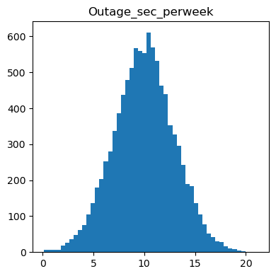

```python
fig, ax = plt.subplots(figsize=(4, 4))
ax.hist(df_raw.loc[:,Variable],bins = 50)  #plotting Histogram
ax.set_title(Variable)
plt.tight_layout()
plt.show()
```

This Continuous variable matches very well the normal distribution (bell curve) To test the degree of matching with the typical Normal distribution using the method scipy.stats.probplot to create the QQ-Plot: (Bruce et al.,2020)

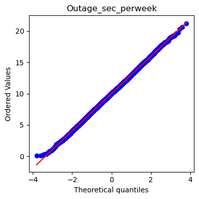

```python
fig, ax = plt.subplots(figsize=(4, 4))
norm_sample = stats.norm.rvs(size=100)
stats.probplot(df_raw[Variable], plot=ax) # QQ-Plot
ax.set_title(Variable)
plt.tight_layout()
plt.show()
```

###### Continuous variable 2: "Bandwidth_GB_Year"

```python
Variable = 'Bandwidth_GB_Year'
df_raw[Variable].describe()
```

```
count    10000.000000
mean      3392.341550
std       2185.294852
min        155.506715
25%       1236.470827
50%       3279.536903
75%       5586.141369
max       7158.981530
Name: Bandwidth_GB_Year, dtype: float64
```

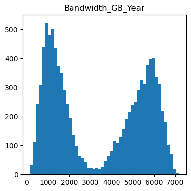

```python
fig, ax = plt.subplots(figsize=(4, 4))
ax.hist(df_raw.loc[:,Variable],bins = 50)  #plotting Histogram
ax.set_title(Variable)
plt.tight_layout()
plt.show()
```

This Continuous variable is clearly Bi-modal and doesn't match the normal distribution , To test the degree of matching with the typical Normal distribution using the method scipy.stats.probplot to create the QQ-Plot: (Bruce et al.,2020)

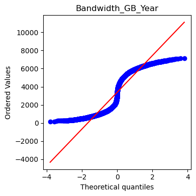

```python
fig, ax = plt.subplots(figsize=(4, 4))
norm_sample = stats.norm.rvs(size=100)
stats.probplot(df_raw[Variable], plot=ax) # QQ-Plot
ax.set_title(Variable)
plt.tight_layout()
plt.show()
```

###### Categorical variable 1: "Contract"

```python
Variable = "Contract"
print(df_raw[Variable].describe()[:],"\n", df_raw[Variable].value_counts())
```

```
count              10000
unique                 3
top       Month-to-month
freq                5456
Name: Contract, dtype: object
 Month-to-month    5456
Two Year          2442
One year          2102
Name: Contract, dtype: int64
```

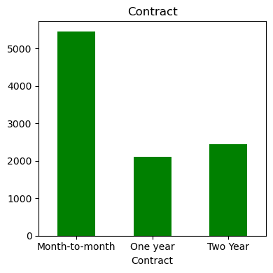

```python
fig, ax = plt.subplots(figsize=(4, 4))
df_raw.groupby(Variable).size().plot.bar(rot=0,color='g') #plotting Bar chart
ax.set_title(Variable)
plt.tight_layout()
plt.show()
```

###### Categorical variable 2: "Gender"

```python
Variable = "Gender"
print(df_raw[Variable].describe()[:],"\n", df_raw[Variable].value_counts())
```

```
count      10000
unique         3
top       Female
freq        5025
Name: Gender, dtype: object
 Female       5025
Male         4744
Nonbinary     231
Name: Gender, dtype: int64
```

```python
Variable = "Gender"
df_raw[Variable].value_counts()
```

```
Female       5025
Male         4744
Nonbinary     231
Name: Gender, dtype: int64
```

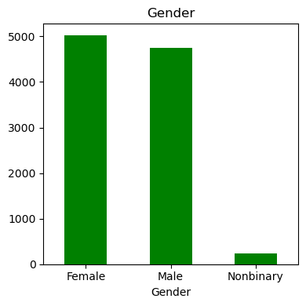

```python
Variable = "Gender"
fig, ax = plt.subplots(figsize=(4, 4))
df_raw.groupby(Variable).size().plot.bar(rot=0,color='g') #plotting Bar chart
ax.set_title(Variable)
plt.tight_layout()
plt.show()
```

###### -------------------------------------------------------------------------------------------------------------------------------------------------------------------------------------------------------

#### D. Identify the distribution of two continuous variables and two categorical variables using bivariate statistics from your cleaned and prepared data. Represent your findings in Part D, visually as part of your submission.

###### Continuous variable 1: "Tenure" vs. "Bandwidth_GB_Year"

This is an example of a very hihgh correlation coef. between two Continuous variables.

```python
Variable1 = "Tenure"
Variable2 = "Bandwidth_GB_Year"
print(df_raw.loc[:,[Variable1,Variable2]].corr())
```

```
                     Tenure  Bandwidth_GB_Year
Tenure             1.000000           0.991495
Bandwidth_GB_Year  0.991495           1.000000
```

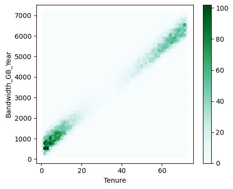

```python
fig, ax = plt.subplots(figsize=(5, 4))
#ax.scatter(df_raw.loc[:,Variable1],df_raw.loc[:,Variable2],s=0.5,alpha=0.6) #plotting scatterd plot
ax = df_raw.plot.hexbin(ax=ax,x=Variable1, y=Variable2,gridsize=50, sharex=False) #plotting hexbin plot
ax.set_xlabel(Variable1)
ax.set_ylabel(Variable2)
plt.tight_layout()
plt.show()
```

###### Continuous variable 2: "MonthlyCharge" vs. "Outage_sec_perweek"

This is an example of a very low correlation coef. between two Continuous variables.

```python
Variable1 = "MonthlyCharge"
Variable2 = "Outage_sec_perweek"
print(df_raw.loc[:,[Variable1,Variable2]].corr())
```

```
                    MonthlyCharge  Outage_sec_perweek
MonthlyCharge            1.000000            0.020496
Outage_sec_perweek       0.020496            1.000000
```

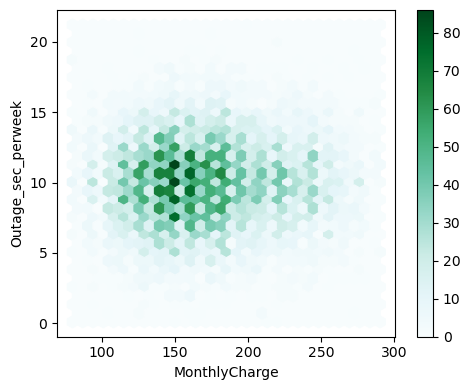

```python
fig, ax = plt.subplots(figsize=(5, 4))
#ax.scatter(df_raw.loc[:,Variable1],df_raw.loc[:,Variable2],s=0.5,alpha=0.6) #plotting scatterd plot
ax = df_raw.plot.hexbin(ax=ax,x=Variable1, y=Variable2,gridsize=30, sharex=False) #plotting hexbin plot
ax.set_xlabel(Variable1)
ax.set_ylabel(Variable2)
plt.tight_layout()
plt.show()
```

###### Categorical variable 1: "Contract" vs. "Churn"

Using cross table function to describe the relationship among different categories of the two categorical variables

```python
Variable1 = "Contract"
Variable2 = "Churn"
rows,colms=Variable1,Variable2
df_crostab=pd.crosstab(index=df_raw[rows],columns=df_raw[colms],margins = True)
df_crostab
```

| Churn Contract | No | Yes | All |
| --- | --- | --- | --- |
| Month-to-month | 3422 | 2034 | 5456 |
| One year | 1795 | 307 | 2102 |
| Two Year | 2133 | 309 | 2442 |
| All | 7350 | 2650 | 10000 |

```python
# Percentage cross-table
df_crostab.div(df_crostab['All'], axis=0)
```

| Churn Contract | No | Yes | All |
| --- | --- | --- | --- |
| Month-to-month | 0.627199 | 0.372801 | 1.0 |
| One year | 0.853949 | 0.146051 | 1.0 |
| Two Year | 0.873464 | 0.126536 | 1.0 |
| All | 0.735000 | 0.265000 | 1.0 |

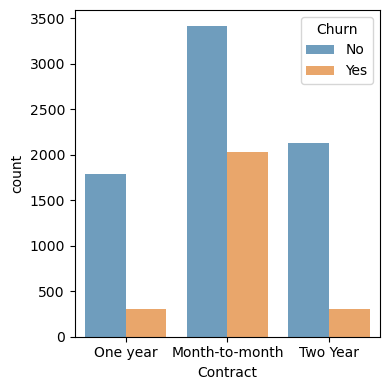

```python
fig, ax = plt.subplots(figsize=(4, 4))
sns.countplot(ax=ax, data = df_raw,x = Variable1,hue = Variable2 ,alpha=0.7) #plotting countplot of cat. variables against the 'Churn' column
plt.tight_layout()
plt.show()
```

###### Categorical variable 2: "StreamingTV" vs. "Churn"

Using cross table function to describe the relationship among different categories of the two categorical variables

```python
Variable1 = "StreamingTV"
Variable2 = "Churn"
rows,colms=Variable1,Variable2
df_crostab=pd.crosstab(index=df_raw[rows],columns=df_raw[colms],margins = True)
df_crostab
```

| Churn StreamingTV | No | Yes | All |
| --- | --- | --- | --- |
| No | 4235 | 836 | 5071 |
| Yes | 3115 | 1814 | 4929 |
| All | 7350 | 2650 | 10000 |

```python
# Percentage cross-table
df_crostab.div(df_crostab['All'], axis=0)
```

| Churn StreamingTV | No | Yes | All |
| --- | --- | --- | --- |
| No | 0.835141 | 0.164859 | 1.0 |
| Yes | 0.631974 | 0.368026 | 1.0 |
| All | 0.735000 | 0.265000 | 1.0 |

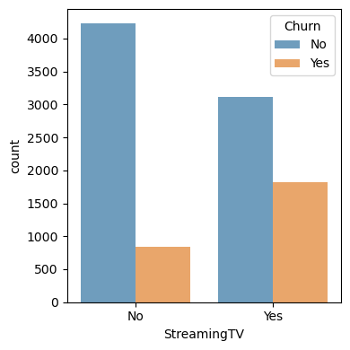

```python
fig, ax = plt.subplots(figsize=(4, 4))
sns.countplot(ax=ax, data = df_raw,x = Variable1,hue = Variable2 ,alpha=0.7) #plotting countplot of cat. variables against the 'Churn' column
plt.tight_layout()
plt.show()
```

###### -------------------------------------------------------------------------------------------------------------------------------------------------------------------------------------------------------

#### E. Summarize the implications of your data analysis by doing the following:

###### E1. Discuss the results of the hypothesis test.

The null hypothesis assumes that there is no relationship between the tested categorical variable and the "Churn". The alternative hypothesis is that the variation in Churn with the variation in a tested categorical variable is confidently not due to chance.

If the alpha statistics is set to be 0.05 (or confidence 95%), a p-value less than 0.05 means we have enough evidence to reject the null hypothesis at the 95% confidence levels, and accepting the alternative hypothesis, hence the proportions of Churn is dependent (has a relationship with) the groups in the tested categorical variable. (D207:performance lab python - 3.10.1)

Using the Chi2 test was very beneficial in identifying the categorical features that can explain a significant amount of variance in the 'Churn' variable such as "Contract", "StreamingMovies" , "StreamingTv" ,"Multiple" and "InternetService" by comparing observed vs. expected values.

###### E2. Discuss the limitations of your data analysis.

Using the Chi2 test was very beneficial in identifying the categorical features that can explain a significant amount of variance in the 'Churn' variable such as "Contract" and "StreamingMovies", but it wasn't so successful with the continuous features such as "Bandwidth_GB_Year" and "Tenure", even though both showed considerable correlation with the "Churn" variable. With such continuous variables, the Chi2 test can't determine specific categories to compare observed vs. expected values.

###### E3. Recommend a course of action based on your results.

Both correlation and Chi2 tests showed clear relationships between customers "Churn" probability and several continuous and categorical features from the dataset. continuous variables such as: "Tenure", "Bandwidth_GB_Year" and "MonthlyCharge", in addition to "CaseOrder" (even though it's just an index of the records, but it has an obvious relationship with "Churn") categorical variables such as: "Contract", "StreamingMovies" , "StreamingTv" ,"Multiple" and "InternetService" each feature should be investigated separately and it's easy to recognise the effect of some of them on the customers Churn probability.

###### -------------------------------------------------------------------------------------------------------------------------------------------------------------------------------------------------------

#### F. Provide a Panopto video recording that includes a demonstration of the functionality of the code used for the analysis and a summary of the tool(s) used.

https://wgu.hosted.panopto.com/Panopto/Pages/Viewer.aspx?id=4b7a6a14-3a26-45b2-b220-acfc00556019

###### -------------------------------------------------------------------------------------------------------------------------------------------------------------------------------------------------------

#### G- References:

1- Bruce, P. C., Bruce, A., & Gedeck, P. (2020). Practical statistics for data scientists: 50 essential concepts. Sebastopol, CA: O'Reilly Media, Incorporated.

2- https://github.com/gedeck/practical-statistics-for-data-scientists/blob/master/python/notebooks/Chapter%201%20-%20Exploratory%20Data%20Analysis.ipynb

3- (WGU) Exploratory Data Analysis – D207 course materials and Labs

4- General Questions/Answers from https://stackoverflow.com/

5- Documentation of Python packages: pandas, matplotlib,numpy,seaborn and scipy